# 1 Neural Networks

The previous chapter covers the design and implementation of an individual neuron. This chapter builds upon the effort initiated in previous chapters by connecting multiple neurons. We provide a complete implementation of a neural network and a backpropagation algorithm, which bring us at the core of the first part of the book.

## 1.1 General architecture

An artificial neural network is a computing system inspired by biological neural networks part of an animal brain. An artificial neural network is a collection of connected artificial neurons. Each connection between artificial neurons can transmit a signal from one to another. The artificial neuron that receives the signal can process it, and then signal neurons connected to it. Artificial neural networks are commonly employed to perform particular tasks, including clustering, classification, prediction, and pattern recognition. Similarly than with the perceptron and sigmoid neuron, a neural network acquires knowledge through learning.

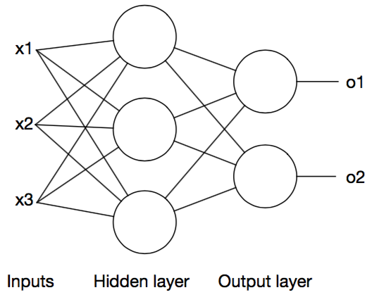

Figure 1: Example of a neural network

Figure 1 shows a simple neural network made of five neurons, three inputs, and two outputs. The left-most column is called the input layer. The input layers simply transmits some values to the hidden layer, without doing anything in particular. In the figure, the input layer is made of three inputs, `x1`, `x2`, and `x3`. The middle of the network contains the hidden layers. The network above contains only one hidden layer, made of three neurons. However, a network may contains several hidden layers. The right-most column of the network is called output layer, and contains two neurons.

All values transmitted between neurons are numerical values. The output values, `o1` and `o2` are number ranging between 0 and 1. Since all the neurons we will consider have a sigmoid activation function, only values ranging between 0 and 1 are transmitted between neuron layers.

The depicted neural network is qualified as *fully-connected* since each neuron of the hidden layer is connected with *all* the neurons of the input layer and *all* the neurons of the output layer. Such a network corresponds to the simplest architecture. More sophisticated architecture may be recurrent neural network and convolutional neural networks, which are not covered by the present book.

This chapter provides an implementation of abstraction we informally presented. The next chapter will uncover some theoretical aspects of the fully-connected network.

## 1.2 Neural layer

We define a layer as a set of neurons. Layers are connected between them, and a set of layers form a neural network. We will represent a layer with the `NeuronLayer` class.

```
Object subclass: #NeuronLayer
    instanceVariableNames: 'previousLayer nextLayer neurons'
    classVariableNames: ''
    package: 'NeuralNetwork'
```

A layer contains some neurons, kept in the variable `neurons`. We can set the learning rate of a layer as 0.1 per default. A neuron layer may be initialized using the following method:

```
NeuronLayer>>initializeNbOfNeurons: nbOfNeurons nbOfWeights: nbOfWeights using: random
    "Main method to initialize a neuron layer
    nbOfNeurons : number of neurons the layer should be made of
    nbOfWeights : number of weights each neuron should have
    random : a random number generator
    "
    | weights |
    neurons := (1 to: nbOfNeurons) collect: [ :i |
        weights := (1 to: nbOfWeights) collect: [ :ii | random next * 4 - 2 ].
        Neuron new sigmoid; weights: weights; bias: (random next * 4 - 2) ].
    self learningRate: 0.1
```

The method `initializeNbOfNeurons:nbOfWeights:using:` accepts three arguments. The first one, `nbOfNeurons` is an integer value and represents the number of neurons the layer should contains. The second argument, `nbOfWeights`, is an integer that indicates the number of weights each neuron should have. This number of weights reflects the number of input values the layer is accepting. The last argument, `random`, is a random number generator. As in the previous chapter, using a random number generator is useful to make the behavior deterministic. This random generator is used to initialize each individual neuron.

The method first creates `nbOfNeurons` different neurons, each having `nbOfWeights` weight values. Each weight is a random number between $-2$ and $+2$. These boundary are arbitrary chosen. The expression `random next` produces a random number within 0 and 1. Multiplying it by 4 and subtracting 2 produces a value between -2 and +2. Each neuron has a sigmoid activation function thanks to the message `sigmoid`.

Lastly, the method set the learning rate of each neuron at `0.1`. The method `learningRate:` is defined as:

```
NeuronLayer>>learningRate: aLearningRate
    "Set the learning rate for all the neurons
    Note that this method should be called after configuring the network, and _not_ before"
    self assert: [ neurons notEmpty ] description: 'learningRate: should be invoked after configuring the layer'.
    neurons do: [ : n | n learningRate: aLearningRate ]
```

Forward feeding the layer is an essential operation. It consists in feeding each neuron and forwarding the values to the next layer. We define the method `feed:` as:

```
NeuronLayer>>feed: someInputValues
    "Feed the neuron layer with some inputs"

    | someOutputs |
    someOutputs := neurons collect: [ :n | n feed: someInputValues ] as: Array.
    ^ self isOutputLayer
        ifTrue: [ someOutputs ]
        ifFalse: [ nextLayer feed: someOutputs ]
```

The method invokes `feed:` on each of its neurons (the method `Neuron>>feed:` is detailed in the previous chapter). The results is then kept as an array. The method then checks if the layer is an output layer. If this is the case, the result of the method is simply the results of each neurons. If the layer is not an output (*i.e.,* it is an hidden layer), we feed-forward the computed values to the next layer.

We need to determine if a neuron layer is the output layer or not. We can easily achieve this using the predicate `isOutputLayer`:

```
NeuronLayer>>isOutputLayer
    "Return true of the layer is the output layer (i.e., the last layer, right-most, in the network)"
    ^ self nextLayer isNil
```

We will also need a way to hook layers together:

```
NeuronLayer>>nextLayer: aLayer
    "Set the next layer"
    nextLayer := aLayer
```

To access the next layer, we need the method:

```
NeuronLayer>>nextLayer
    "Return the next layer connected to me"
    ^ nextLayer
```

Similarly, we need a way to set and access the previous layer:

```
NeuronLayer>>previousLayer: aLayer
    "Set the previous layer"
    previousLayer := aLayer
```

Similarly:

```
NeuronLayer>>previousLayer
    "Return the previous layer connected to me"
    ^ previousLayer
```

Neurons for a given layer needs to be accessed:

```
NeuronLayer>>neurons
    "Return the neurons I am composed of"
    ^ neurons
```

We also need the size of the layer to be accessible:

```
NeuronLayer>>numberOfNeurons
    "Return the number of neurons in the layer"
    ^ neurons size
```

We have now defined most of the `NeuronLayer` class. We can now begin testing the class:

```
TestCase subclass: #NeuronLayerTest
    instanceVariableNames: ''
    classVariableNames: ''
    package: 'NeuralNetwork'
```

A simple test may be:

```
NeuronLayerTest>>testBasic
    | nl result r |
    r := Random seed: 42.
    nl := NeuronLayer new.
    nl initializeNbOfNeurons: 3 nbOfWeights: 4 using: r.

    self assert: nl isOutputLayer.

    result := nl feed: #(1 2 3 4).
    self assert: result size equals: 3.
    result
        with: #(0.03700050130978758 0.9051275824569505 0.9815269659126287)
        do: [ :res :test | self assert: (res closeTo: test precision: 0.0000000001) ]
```

The method `testBasic` creates a new neuron layer, composed of 3 neurons, each having 4 weights and 1 bias. The weights and biases are initialized using the random number generator `r`.

We can also build up a chain of layers and see how they perform:

```
NeuronLayerTest>>testOutputLayer
    | nl1 nl2 result random |
    random := Random seed: 42.
    nl1 := NeuronLayer new.
    nl1 initializeNbOfNeurons: 3 nbOfWeights: 4 using: random.
    nl2 := NeuronLayer new.
    nl2 initializeNbOfNeurons: 4 nbOfWeights: 3 using: random.
    nl1 nextLayer: nl2.
    self deny: nl1 isOutputLayer.
    self assert: nl2 isOutputLayer.
    result := nl1 feed: #(1 2 3 4).
    "Since nl2 has 4 neurons, we will obtain 4 outputs"
    self assert: result size equals: 4.
    result
        with: #(0.03089402289518759 0.9220488835263312 0.5200462953493654 0.20276557516858304)
        do: [ :r :test | self assert: (r closeTo: test precision: 0.0000000001) ]
```

We can now wrap a chain of layers into a neural network.

## 1.3 Neural Network

We will represent a neural network as an instance of the class `NNetwork`:

```
Object subclass: #NNetwork
    instanceVariableNames: 'layers errors precisions'
    classVariableNames: ''
    package: 'NeuralNetwork'
```

We define a neural network simply as a container of layers. We also add an `errors` instance variable that will be useful to trace the evolution of error during the learning phase.

The initialization of a network is done through the method `initialize`:

```
NNetwork>>initialize
    super initialize.
    layers := OrderedCollection new.
    errors := OrderedCollection new.
    precisions := OrderedCollection new.
```

Both the `layers`, `errors`, and `precisions` instance variables are initialized with an empty collection. The variable `layers` will contains instances of the class `NeuronLayer`. The variables `errors` and `precisions` will contains numerical values, representing the errors and precisions during the training process. We will exploit these variables when we will classify data, in a future chapter.

Adding a layer is simply done through the method `addLayer:`, which takes a layer as argument:

```
NNetwork>>addLayer: aNeuronLayer
    "Add a neural layer. The added layer is linked to the already added layers."
    layers ifNotEmpty: [
        aNeuronLayer previousLayer: layers last.
        layers last nextLayer: aNeuronLayer ].
    layers add: aNeuronLayer.
```

Layers are linked to each other. When a layer is added, it is linked to the previous layer and that layer is linked to the added layer.

Feeding a neural network is simply feeding the first hidden layer:

```
NNetwork>>feed: someInputValues
    "Feed the first layer with the provided inputs"
    ^ layers first feed: someInputValues
```

We need a way to easily create a neural network. In case we wish to build a network with one hidden layer and one output layer, we can define the following method:

```
NNetwork>>configure: nbOfInputs hidden: nbOfNeurons nbOfOutputs: nbOfOutput
    "Configure the network with the given parameters
    The network has only one hidden layer"
    | random |
    random := Random seed: 42.
    self addLayer: (NeuronLayer new initializeNbOfNeurons: nbOfNeurons nbOfWeights: nbOfInputs using: random).
    self addLayer: (NeuronLayer new initializeNbOfNeurons: nbOfOutput nbOfWeights: nbOfNeurons using: random).
```

In case we wish to have two hidden layers and one output layer:

```
NNetwork>>configure: nbOfInputs hidden: nbOfNeurons1 hidden: nbOfNeurons2 nbOfOutputs: nbOfOutput
    "Configure the network with the given parameters
    The network has only one hidden layer"
    | random |
    random := Random seed: 42.
    self addLayer: (NeuronLayer new initializeNbOfNeurons: nbOfNeurons1 nbOfWeights: nbOfInputs using: random).
    self addLayer: (NeuronLayer new initializeNbOfNeurons: nbOfNeurons2 nbOfWeights: nbOfNeurons1 using: random).
    self addLayer: (NeuronLayer new initializeNbOfNeurons: nbOfOutput nbOfWeights: nbOfNeurons2 using: random).
```

We also need a way to obtain the number of outputs a neural network can have (we will need this in the chapter about data classification):

```
NNetwork>>numberOfOutputs
    "Return the number of output of the network"
    ^ layers last numberOfNeurons
```

The class `NNetwork` defines the method `learningRate:` to set the learning rate for each layers:

```
NNetwork>>learningRate: aLearningRate
    "Set the learning rate for all the layers"
    layers do: [ :l | l learningRate: aLearningRate ]
```

The method `learningRate:` is useful to set a unique learning rate for all the neurons composing our network. The basic functionalities are now defined. We can test our network implementation:

```
TestCase subclass: #NNetworkTest
    instanceVariableNames: ''
    classVariableNames: ''
    package: 'NeuralNetwork'
```

Our first test could be:

```
NNetworkTest>>testBasic
    | n |
    n := NNetwork new.
    n configure: 2 hidden: 2 nbOfOutputs: 1.
    self assert: ((n feed: #(1 3)) anyOne closeTo: 0.6745388083637036 precision: 0.0000000001).
    self assert: n numberOfOutputs equals: 1
```

As you can see, `testBasic` is rather simplistic. It builds a simple network with two inputs, one hidden layer made of 2 neurons, and an output layer with only one neuron, and run the forward feeding.

So far, our network is pretty useless as it can only feed-forward some values along a set of neurons randomly initialized. The output are therefore random values. The next section covers the learning mechanism for neural networks.

## 1.4 Backpropagation

Backpropagation is an algorithm commonly employed to train neural networks. The purpose of the backpropagation algorithm is to find a set of neuron weights and biases to reduce the network prediction error.

So far, we built a network as a set of neurons, each being initialized with random weights and random biases. Conceptually, backpropagation is an algorithm for supervised learning of gradient descent (next chapters will cover this terminology). In practice, this algorithm will find adequate weights and biases to identify patterns from the input values. This section focuses on informally presenting the algorithm and providing an implementation of it. The next chapter will provide a theoretical foundation of the algorithm. This chapter covers mostly the implementation of this theory.

The backpropagation algorithm is composed of three steps:

1. *Forward feeding the inputs*. We first activate each neurons of our network to make the network produce an output. As we have previously seen, this forward feeding goes from the left-most layer to the output layer.
2. *Backward propagating the errors through the network*. The output produced in the previous step has to be contrasted with the actual training dataset. We can therefore compute the error made by the network. This error is key to indicate how far our network is from correctly predicting the training set. This backward propagation goes from the right-most layer (i.e., the output layer) to the left-most layer (i.e., the first hidden layer).
3. *Updating the neurons weights and biases*. From the error computed in the previous step, we adequately adjust each neuron weights and bias to, hopefully, reduce the error made by the network. In our implementation, we will start it from the left-most layer until the output layer.

### 1.4.1 Step 1: Forward feeding

The first step is mostly implemented by the method `NNetwork>>feed:`, however, we need to slightly improve the class `Neuron` to actually remember the produced output. During the forward feeding (*i.e.,* when the method `feed:` is called), an output is produced by each neuron. This output has to be compared with an expected output during the second step. Making the network learn is based on the difference between the actual output of a neuron and the expected output. Each neuron has therefore to keep a reference of its output.

We add two variables, `delta` and `output`, to the `Neuron` class. So, our new definition of `Neuron` is:

```
Object subclass: #Neuron
    instanceVariableNames: 'weights bias learningRate activationFunction delta output'
    classVariableNames: ''
    package: 'NeuralNetwork'
```

The delta value has to be accessible from outside:

```
Neuron>>delta
    "Return the delta value computed when propagating the error"
    ^ delta
```

We also need to rewrite the method `feed:` in the class `Neuron` to remember the output value:

```
Neuron>>feed: inputs
    | z |
    z := (inputs with: weights collect: [ :x :w | x * w ]) sum + bias.
    output := activationFunction eval: z.
    ^ output
```

We also need to access the output value for a given neuron:

```
Neuron>>output
    "Return the output value, previous computed when doing a feed:"
    ^ output
```

At that stage, it is important to run the unit tests we have previously defined. In particular, we need to make sure that the small changes we have defined on the class `Neuron` does not break any invariant. We are now done with the first phase of the backpropagation.

*EXERCISE:* Run the unit tests written in the previous chapter. This is important to verify whether no functional invariant is affected by our recent modifications.

### 1.4.2 Step 2: Error backward propagation

The second step of the backpropagation consists in propagating the errors computed at the output layer back in the network. We define the following method:

```
NNetwork>>backwardPropagateError: expectedOutputs
    "expectedOutputs corresponds to the outputs we are training the network against"
    self outputLayer backwardPropagateError: expectedOutputs
```

The argument of `backwardPropagateError:` corresponds to the expected output values used during the learning phase.

And the following helper method:

```
NNetwork>>outputLayer
    "Return the output layer, which is also the last layer"
    ^ layers last
```

We add the method `backwardPropagateError:` to back propagate the error from the output layer:

```
NeuronLayer>>backwardPropagateError: expected
    "This is a recursive method. The back propagation begins with the output layer (i.e., the last layer)"
    "We are in the output layer"
    neurons with: expected do: [ :neuron :exp |
        | theError |
        theError := exp - neuron output.
        neuron adjustDeltaWith: theError ].

    "We iterate"
    self previousLayer notNil
        ifTrue: [
             self previousLayer backwardPropagateError ].
```

The method `backwardPropagateError:` takes as argument the expected output values. It computes the error for each neuron in the output layers and call the method `adjustDeltaWith:`. We will soon see this method.

Once the neuron in the output layer have their delta value adjusted, previous layers have to be recursively updated. The method `backwardPropagateError` exactly implements this behavior:

```
NeuronLayer>>backwardPropagateError
    "This is a recursive method. The back propagation begins with the output layer (i.e., the last layer)"

    "We are in an hidden layer"
    neurons doWithIndex: [ :neuron :j |
        | theError |
        theError := 0.0.
        self nextLayer neurons do: [ :nextNeuron |
            theError := theError + ((nextNeuron weights at: j) * nextNeuron delta)
        ].
        neuron adjustDeltaWith: theError
    ].

    self previousLayer notNil
        ifTrue: [
             self previousLayer backwardPropagateError ].
```

The recursion end on the first hidden layer, which is the layer with no previous layer. Note that we do not explicitly model the input layer since there is no use of it. We also need the following helper method on the class `Neuron`:

```
Neuron>>adjustDeltaWith: anError
    delta := anError * (activationFunction derivative: output)
```

We are now done with the second phase. Only the third phase remains to be implemented in order to have a functional neural network.

### 1.4.3 Step 3: Updating neurons parameters

Luckily, the third phase is rather simple. We recursively update the weights and biases based on the delta computed in the previous step. The main method is `updateWeight:`:

```
NNetwork>>updateWeight: initialInputs
    "Update the weights of the neurons using the initial inputs"
    layers first updateWeight: initialInputs
```

This method simply invokes `updateWeight:` on each first hidden layer:

```
NeuronLayer>>updateWeight: initialInputs
    "Update the weights of the neuron based on the set of initial input. This method assumes that the receiver of the message invoking that method is the first hidden layer."
    | inputs |
    inputs := initialInputs.

    neurons do: [ :n |
        n adjustWeightWithInput: inputs.
        n adjustBias ].

    self nextLayer ifNotNil: [
        self nextLayer updateWeight ]
```

The recursion happens in the method `updateWeight`:

```
NeuronLayer>>updateWeight
    "Update the weights of the neuron based on the set of initial input. This method assumes that the receiver of the message invoking that method is the first hidden layer.
    We are now in the second hidden layers or in the output layer"
    | inputs |
    inputs := self previousLayer neurons collect: #output.

    self updateWeight: inputs
```

And we need the following methods to update a neuron’s weights:

```
Neuron>>adjustWeightWithInput: inputs
    inputs withIndexDo: [ :anInput :index |
        weights at: index put: ((weights at: index) + (learningRate * delta * anInput)) ]
```

We also need to update the bias:

```
Neuron>>adjustBias
    bias := bias + (learningRate * delta)
```

This ends the third and last phase of the backpropagation algorithm. We are now ready to hook the backpropagation phases all together:

```
NNetwork>>train: someInputs desiredOutputs: desiredOutputs
    "Train the neural network with a set of inputs and some expected output"
    self feed: someInputs.
    self backwardPropagateError: desiredOutputs.
    self updateWeight: someInputs
```

And Voila! We have implemented the necessary to train a neural network.

We can now test our network with the XOR example:

```
NNetworkTest>>testXOR
    | n |
    n := NNetwork new.
    n configure: 2 hidden: 3 nbOfOutputs: 1.

    20000 timesRepeat: [
        n train: #(0 0) desiredOutputs: #(0).
        n train: #(0 1) desiredOutputs: #(1).
        n train: #(1 0) desiredOutputs: #(1).
        n train: #(1 1) desiredOutputs: #(0).
    ].

    self assert: (n feed: #(0 0)) first < 0.1.
    self assert: (n feed: #(0 1)) first > 0.9.
    self assert: (n feed: #(1 0)) first > 0.9.
    self assert: (n feed: #(1 1)) first < 0.1.
```

If you try to decrease the `20000` to a low value, `1000` for example, the network does not receive enough training and the test ultimately fails.

## 1.5 What have we seen in this chapter

This chapter covers the following topics:

- *Presented the general architecture of a fully-connected network*. This architecture drove our implementation effort.
- *Implemented a neural network library*. We build a small API to build neural networks.
- *Implemented the backpropagation algorithm*. Making neural network learn is a fundamental operation to give a meaning to a network. A properly trained network is able to identify patterns. This chapter ends with a trivial example, the XOR logical gate. The coming chapters will see real and representative examples.